# Introduction to gtfs2emis

Joao Bazzo, Rafael H. M. Pereira, Pedro R. Andrade

2022-05-01

Abstract

Advanced functionalities to estimate public transport emissions using the `gtfs2emis` package

# Introduction

The package `gtfs2emis` helps users estimate hot exhaust emissions of public transport systems based on GTFS and fleet characteristics data.

# Installation

You can install `gtfs2emis`:

```r
# From CRAN
install.packages("gtfs2emis")

# or use the development version with latest features
utils::remove.packages('gtfs2emis')
devtools::install_github("ipeaGIT/gtfs2emis")
```

This vignette introduces the main functions of the `gtfs2mies` package. We will be using the following packages:

```r
library(gtfs2emis)
library(gtfstools)
library(gtfs2gps)
```

```r
library(data.table)
library(sf)
library(units)
library(magrittr)
library(ggplot2)
```

# Approach

The package has two main usages that will ultimately depend on the user’s experience and on the desired output:

**1. Basic usage**

- Emissions inventory is straightforward, making it more friendly for new users;
- It is divided into `transport_model()` and `emissions_model()` functions;
- In the `emissions_model()` the user specifies the source of emission factors;
- It uses several default approaches for hot exhaust emissions inventory;
- It considers the fleet to be homogeneously distributed across the vehicle routes.

**2. Detailed usage**

- It uses step-by-step functions to produce the transport and emissions model: User can specific any correction on speed distribution over routes;
- It allocates specific vehicles into predefined routes, e.g. articulated buses into specific shape_id’s;
- It adjusts emissions factors (fuel correction, scaling non-speed dependent emission factors with Environmental European Agency (EMEP-EEA) emissions factors, checking emission factors before using in the inventory).

## Basic Usage

**1. Read data**  
The first step selects the GTFS and the desired route to model emissions. Here we use one example of `shape_id == "176-1"` in Porto Alegre (Brazil). Detailed functions of GTFS editing can be found in `gtfs2gps` and `gtfstools` packages.

```r
gtfs <- read_gtfs(system.file("extdata/poa.zip", package = "gtfs2gps")) %>%
  filter_week_days() %>%
  filter_by_shape_id(., "176-1") %>%
  filter_single_trip()
```

**2. Transport model**  
The `transport_model()` accepts either a GTFS data or a filepath where the data is stored. It converts the GTFS into a GPS-like data.table, fixing extreme or missing values of speed and transforming the output into a sf-linestring, which is the required input for emissions estimates.

```r
sf_line <- transport_model(gtfs = gtfs,parallel = TRUE)
```

Visualizing the transport model output for `shape_id == "176-1"` of Porto Alegre (Brazil).

```r
head(sf_line$geometry)
```

```
#> Geometry set for 2 features
#> Geometry type: LINESTRING
#> Dimension:     XY
#> Bounding box:  xmin: -51.25528 ymin: -30.16306 xmax: -51.217 ymax: -30.02311
#> Geodetic CRS:  WGS 84
```

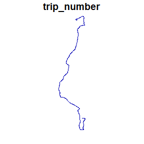

```r
sf_line <- sf::st_as_sf(sf_line)
plot(sf_line["trip_number"])
```

**3. Fleet data**  
After generating the transport model, we advance to estimate the hot exhaust emissions. We create a data.frame with fleet information, which can also be imported from an external file. There are two main key features of fleet data:

- If the user has fleet data but does not have information on the relations between buses and routes (e.g Articulated buses to `shape_id` `XX`, `YY` or `ZZ`), she can assign a probability of each fleet type into the routes. If the class of a given route is known, the probability is equals to 1, always assigning the same class to the route. The sum of all probabilities of each route must be one.
- The fleet data needs to be organized according to the desired emission factor database. For instance, if the user wants to estimate emissions based on typical European fleet, she must present the data according to the typical emission factors inputs for Emep-EEA methodology. In this example, the data is organized according to the requirements for `ef_emep_europe()` emission factor data. Users can check in `ef_moves_usa()`, `ef_emfac_usa()`, `ef_cetesb_brazil()` or `ef_emep_europe()` how the fleet must be organized.

In the example of European emission factors, we use three vehicles classes. A given `shape_id` has 40%, 50%, and 10% chance of having `Ubus Midi <=15 t`, `Ubus Std 15 - 18 t`, and `Ubus Artic >18 t`, respectively.

```r
fleet_data_ef_europe <- data.table::data.table("veh_type" = c("Ubus Midi <=15 t"
                                                              ,"Ubus Std 15 - 18 t"
                                                              ,"Ubus Artic >18 t")
                                               ,"euro" = c("III","IV","V")
                                               ,"fuel" = rep("D",3)
                                               ,"tech" = c("-","SCR","SCR")
                                               ,"fleet_composition" = c(0.4,0.5,0.1))
fleet_data_ef_europe
```

```
#>              veh_type euro fuel tech fleet_composition
#> 1:   Ubus Midi <=15 t  III    D    -               0.4
#> 2: Ubus Std 15 - 18 t   IV    D  SCR               0.5
#> 3:   Ubus Artic >18 t    V    D  SCR               0.1
```

This data.table is quite similar to other emissions factors database sources. Three other examples are described below.

Emission Factor Model (California Air Resources Board):

```r
fleet_data_ef_emfac <- data.table::data.table("veh_type" = "BUS_URBAN_D"
                                              ,"model_year" = 2011:2015
                                              ,"fuel" = "D"
                                              ,"calendar_year" = 2019
                                              ,"fleet_composition" = rep(0.2,5))
fleet_data_ef_emfac
```

```
#>       veh_type model_year fuel calendar_year fleet_composition
#> 1: BUS_URBAN_D       2011    D          2019               0.2
#> 2: BUS_URBAN_D       2012    D          2019               0.2
#> 3: BUS_URBAN_D       2013    D          2019               0.2
#> 4: BUS_URBAN_D       2014    D          2019               0.2
#> 5: BUS_URBAN_D       2015    D          2019               0.2
```

MOtor Vehicle Emission Simulator (MOVES) from Environmental Protection Agency (United States):

```r
fleet_data_ef_moves <- data.table::data.table("veh_type" = "BUS_URBAN_D"
                                              ,"model_year" = 2011:2015
                                              ,"fuel" = "D"
                                              ,"calendar_year" = 2016
                                              ,"fleet_composition" = rep(0.2,5))
fleet_data_ef_moves
```

```
#>       veh_type model_year fuel calendar_year fleet_composition
#> 1: BUS_URBAN_D       2011    D          2016               0.2
#> 2: BUS_URBAN_D       2012    D          2016               0.2
#> 3: BUS_URBAN_D       2013    D          2016               0.2
#> 4: BUS_URBAN_D       2014    D          2016               0.2
#> 5: BUS_URBAN_D       2015    D          2016               0.2
```

Environmental Company of São Paulo (CETESB, Brazil):

```r
fleet_data_ef_cetesb <- data.table::data.table("veh_type" = c("BUS_MICRO_D"
                                                              ,"BUS_URBAN_D"
                                                              ,"BUS_ARTIC_D")
                                               ,"model_year" = rep(2010, 3)
                                               ,"fuel" = rep("D", 3)
                                               ,"fleet_composition" = c(0.4, 0.4, 0.2))
fleet_data_ef_cetesb
```

```
#>       veh_type model_year fuel fleet_composition
#> 1: BUS_MICRO_D       2010    D               0.4
#> 2: BUS_URBAN_D       2010    D               0.4
#> 3: BUS_ARTIC_D       2010    D               0.2
```

```r
sf_emis <- emission_model(gps = sf_line
                          ,ef_data_base = "emep_europe"
                          ,fleet_data = fleet_data_ef_europe
                          ,pollutant = c("CO","PM10","CO2","CH4","NOx"))
class(sf_emis)
```

```
#> [1] "list"
```

```r
names(sf_emis)
```

```
#>  [1] "pollutant"         "veh_type"          "euro"
#>  [4] "fuel"              "tech"              "slope"
#>  [7] "load"              "EF"                "emi"
#> [10] "fleet_composition" "gps"
```

**5. Data post-processing**  
As the results are stored in a long list, gtfs2emis package has several function to post-process the results. `emis_summary` summarizes the emissions according to the variable of interest, such as vehicle type `veh_type`, `pollutant`, or `time`. In the last case, we need to add a `time_column` in the list, as this information is not returned by `emission_model()`.

```r
sf_emis$time_column <- sf_emis$gps$timestamp

names(sf_emis)
```

```
#>  [1] "pollutant"         "veh_type"          "euro"
#>  [4] "fuel"              "tech"              "slope"
#>  [7] "load"              "EF"                "emi"
#> [10] "fleet_composition" "gps"               "time_column"
```

```r
my_emis_summary <- emis_summary(emi_list = sf_emis,
                    emi_var = "emi",
                    by = "time",
                    time_column = "time_column",
                    veh_var = "veh_type",
                    pol_var = "pollutant")
my_emis_summary
```

```
#>    time_column pollutant              emi
#> 1:           6        CO    35.555250 [g]
#> 2:           6      PM10     1.999375 [g]
#> 3:           6       CO2 19685.823245 [g]
#> 4:           6       CH4     1.041536 [g]
#> 5:           6       NOx   146.596574 [g]
```

To visualize results by vehicle type `veh_type`:

```r
my_emis_summary <- emis_summary(emi_list = sf_emis,
                                 emi_var = "emi",
                                 by = "veh_type",
                                 time_column = "time_column",
                                 veh_var = "veh_type",
                                 pol_var = "pollutant")
my_emis_summary
```

```
#>               veh_type pollutant              emi
#>  1:   Ubus Midi <=15 t        CO 1.559449e+01 [g]
#>  2: Ubus Std 15 - 18 t        CO 1.328419e+01 [g]
#>  3:   Ubus Artic >18 t        CO 6.676565e+00 [g]
#>  4:   Ubus Midi <=15 t      PM10 1.304821e+00 [g]
#>  5: Ubus Std 15 - 18 t      PM10 5.441214e-01 [g]
#>  6:   Ubus Artic >18 t      PM10 1.504329e-01 [g]
#>  7:   Ubus Midi <=15 t       CO2 6.592714e+03 [g]
#>  8: Ubus Std 15 - 18 t       CO2 1.044825e+04 [g]
#>  9:   Ubus Artic >18 t       CO2 2.644856e+03 [g]
#> 10:   Ubus Midi <=15 t       CH4 9.677267e-01 [g]
#> 11: Ubus Std 15 - 18 t       CH4 6.150805e-02 [g]
#> 12:   Ubus Artic >18 t       CH4 1.230161e-02 [g]
#> 13:   Ubus Midi <=15 t       NOx 6.504679e+01 [g]
#> 14: Ubus Std 15 - 18 t       NOx 6.753369e+01 [g]
#> 15:   Ubus Artic >18 t       NOx 1.401609e+01 [g]
```

If available in `names(sf_emis)`, it is possible to add extra argument about fleet.

```r
my_emis_summary <- emis_summary(emi_list = sf_emis,
                                emi_var = "emi",
                                by = "veh_type",
                                time_column = "time_column",
                                veh_var = c("veh_type", "euro", "fuel"),
                                pol_var = "pollutant")
my_emis_summary
```

```
#>               veh_type euro fuel pollutant              emi
#>  1:   Ubus Midi <=15 t  III    D        CO 1.559449e+01 [g]
#>  2: Ubus Std 15 - 18 t   IV    D        CO 1.328419e+01 [g]
#>  3:   Ubus Artic >18 t    V    D        CO 6.676565e+00 [g]
#>  4:   Ubus Midi <=15 t  III    D      PM10 1.304821e+00 [g]
#>  5: Ubus Std 15 - 18 t   IV    D      PM10 5.441214e-01 [g]
#>  6:   Ubus Artic >18 t    V    D      PM10 1.504329e-01 [g]
#>  7:   Ubus Midi <=15 t  III    D       CO2 6.592714e+03 [g]
#>  8: Ubus Std 15 - 18 t   IV    D       CO2 1.044825e+04 [g]
#>  9:   Ubus Artic >18 t    V    D       CO2 2.644856e+03 [g]
#> 10:   Ubus Midi <=15 t  III    D       CH4 9.677267e-01 [g]
#> 11: Ubus Std 15 - 18 t   IV    D       CH4 6.150805e-02 [g]
#> 12:   Ubus Artic >18 t    V    D       CH4 1.230161e-02 [g]
#> 13:   Ubus Midi <=15 t  III    D       NOx 6.504679e+01 [g]
#> 14: Ubus Std 15 - 18 t   IV    D       NOx 6.753369e+01 [g]
#> 15:   Ubus Artic >18 t    V    D       NOx 1.401609e+01 [g]
```

Checking the results by pollutant:

```r
my_emis_summary <- emis_summary(emi_list = sf_emis,
                                 emi_var = "emi",
                                 by = "pollutant",
                                 time_column = "time_column",
                                 veh_var = "veh_type",
                                 pol_var = "pollutant")
my_emis_summary
```

```
#>    pollutant              emi
#> 1:        CO    35.555250 [g]
#> 2:      PM10     1.999375 [g]
#> 3:       CO2 19685.823245 [g]
#> 4:       CH4     1.041536 [g]
#> 5:       NOx   146.596574 [g]
```

If the user wants to have all results in a data.table format:

```r
sf_emis$time_column <- sf_emis$gps$timestamp
my_emis_dt <- emi_to_dt(emi_list = sf_emis
                    ,emi_vars = "emi"
                    ,veh_vars = c("veh_type", "euro", "fuel")
                    ,pol_vars = "pollutant"
                    ,segment_vars = "time_column")
head(my_emis_dt, 5)
```

```
#>              veh_type euro fuel pollutant           emi time_column segment_id
#> 1:   Ubus Midi <=15 t  III    D        CO 15.594492 [g]       21720          1
#> 2:   Ubus Midi <=15 t  III    D        CO        NA [g]       24840          2
#> 3: Ubus Std 15 - 18 t   IV    D        CO 13.284193 [g]       21720          1
#> 4: Ubus Std 15 - 18 t   IV    D        CO        NA [g]       24840          2
#> 5:   Ubus Artic >18 t    V    D        CO  6.676565 [g]       21720          1
```

To visualize emissions spatially in a grid, the user nees to provide info about the desired grid. An operation of intersection can be done using `emis_grid()`. Here, we use `vein::make_grid()` to produce a basic grid.

```r
grid_gps <- vein::make_grid(spobj = sf_emis$gps, width =  0.25 / 102.47) # 500 meters
```

```
#> Number of lon points: 16
#> Number of lat points: 58
```

```r
grid_gps <- sf::st_as_sf(grid_gps)
```

```r
names(sf_emis$emi)
```

```
#>  [1] "CO_Euro_III"   "CO_Euro_IV"    "CO_Euro_V"     "PM10_Euro_III"
#>  [5] "PM10_Euro_IV"  "PM10_Euro_V"   "CO2_Euro_III"  "CO2_Euro_IV"
#>  [9] "CO2_Euro_V"    "CH4_Euro_III"  "CH4_Euro_IV"   "CH4_Euro_V"
#> [13] "NOx_Euro_III"  "NOx_Euro_IV"   "NOx_Euro_V"
```

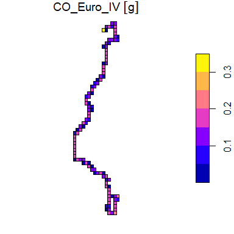

```r
# we add info of emissions into gps file
sf_emis$gps <- cbind(sf_emis$gps,sf_emis$emi)

pol_grid <- emis_grid(data = sf_emis$gps,
                     emi = "CO_Euro_IV",
                     grid = grid_gps,
                     time_class = 'all periods')
plot(pol_grid["CO_Euro_IV"])
```

## Detailed Usage

The detailed usage of `gtfs2emis` has intermediate functions to generate the transport and emissions model. In this case, the user can provide data of fleet distributed according to routes.

**1. Read data**

Users can provide a vehicle specific data for each `shape_id`. The example below shows a situation where the vehicle characteristics is known for three `shape_id`s (`T2-1`,`A141-1`, `176-1`), but is unknown for `R10-2`:

```r
gtfs <- read_gtfs(system.file("extdata/poa.zip", package="gtfs2gps")) %>%
  filter_week_days() %>%
  filter_single_trip()

gtfs$stop_times[,arrival_time := data.table::as.ITime(arrival_time)]
gtfs$stop_times[,departure_time := data.table::as.ITime(departure_time)]

gps_poa <- gtfs2gps(gtfs)
data.table::setDT(gps_poa)
```

We can also define different ranges of minimum and maximum allowed speeds, as well as average speed. In this case, we consider the average speed of 34 km/h.

```r
gps_poa_fix <- adjust_speed(gps_data = gps_poa
                            ,min_speed = 5
                            ,max_speed = 75
                            ,new_speed = 34
                            ,clone = TRUE)
```

To convert the output to linestring:

```r
linestring_poa <- gps_as_sflinestring(gps_poa_fix)
```

Checking some basic statistics of the transport model:

```r
data.table::setDT(linestring_poa)
# speeds
linestring_poa[,weighted.mean(speed,dist),by=shape_id]
```

```
#>    shape_id        V1
#> 1:    176-1 NA [km/h]
#> 2:   A141-1 NA [km/h]
#> 3:    R10-2 NA [km/h]
#> 4:     T2-1 NA [km/h]
```

```r
linestring_poa[,min(dist),by=shape_id]
```

```
#>    shape_id            V1
#> 1:    176-1  60.44233 [m]
#> 2:   A141-1  70.57579 [m]
#> 3:    R10-2  87.13860 [m]
#> 4:     T2-1 114.18493 [m]
```

```r
linestring_poa[,mean(dist),by=shape_id]
```

```
#>    shape_id            V1
#> 1:    176-1 11730.930 [m]
#> 2:   A141-1  2317.287 [m]
#> 3:    R10-2 13362.834 [m]
#> 4:     T2-1  5725.275 [m]
```

```r
linestring_poa[,max(dist),by=shape_id]
```

```
#>    shape_id            V1
#> 1:    176-1 23401.417 [m]
#> 2:   A141-1  6750.871 [m]
#> 3:    R10-2 26638.529 [m]
#> 4:     T2-1 16582.822 [m]
```

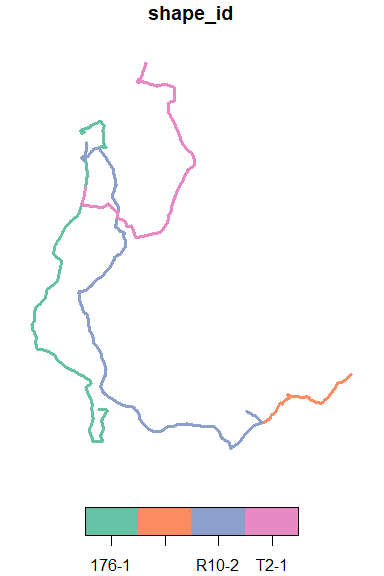

```r
# plot
plot(sf::st_as_sf(linestring_poa)["shape_id"],lwd=3)
```

**2. Fleet**

Users can provide a vehicle specific data for each `shape_id`. The example below shows a situation where the vehicle characteristics is known for three `shape_id`s (`T2-1`,`A141-1`, `176-1`) but is unknown for `R10-2`:

```r
fleet_data_ef_europe <- data.table::data.table("veh_type" = rep(c("Ubus Midi <=15 t"
                                                                  ,"Ubus Std 15 - 18 t"
                                                                  ,"Ubus Artic >18 t"),2)
                                               ,"euro" = rep(c("III","IV","V"),2)
                                               ,"fuel" = rep("D",6)
                                               ,"tech" = rep(c("-","SCR","SCR"),2)
                                               ,"fleet_composition" = c(rep(1,3),0.4,0.5,0.1)
                                               ,"shape_id" = c("T2-1","A141-1",
                                                               "176-1",rep("R10-2",3)))
fleet_data_ef_europe
```

```
#>              veh_type euro fuel tech fleet_composition shape_id
#> 1:   Ubus Midi <=15 t  III    D    -               1.0     T2-1
#> 2: Ubus Std 15 - 18 t   IV    D  SCR               1.0   A141-1
#> 3:   Ubus Artic >18 t    V    D  SCR               1.0    176-1
#> 4:   Ubus Midi <=15 t  III    D    -               0.4    R10-2
#> 5: Ubus Std 15 - 18 t   IV    D  SCR               0.5    R10-2
#> 6:   Ubus Artic >18 t    V    D  SCR               0.1    R10-2
```

The sum of fleet composition per `shape_id` can also be checked:

```r
fleet_data_ef_europe[,sum(fleet_composition),by = shape_id]
```

```
#>    shape_id V1
#> 1:     T2-1  1
#> 2:   A141-1  1
#> 3:    176-1  1
#> 4:    R10-2  1
```

**3. Visualizing the Emission factors**

We use the european database of emission factors (EF). We can plot the EF to check how it behaves according to `speed` and `veh_type`:

```r
ef_europe <- ef_emep_europe(speed = units::set_units(10:100,"km/h")
                            ,veh_type = c("Ubus Midi <=15 t"
                                          ,"Ubus Std 15 - 18 t"
                                          ,"Ubus Artic >18 t")
                            ,euro = c("III", "IV", "V")
                            ,pollutant = c("CO2", "NOx")
                            ,fuel = rep("D", 3)
                            ,tech = c("-", "SCR", "SCR")
                            ,as_list = TRUE)
```

We can use the `emi_to_dt()` to process EF:

```r
ef_europe$speed <- units::set_units(10:100,"km/h")
ef_europe_dt <- emi_to_dt(emi_list = ef_europe
                          ,emi_vars = "EF"
                          ,veh_vars = c("veh_type", "fuel", "euro", "tech")
                          ,pol_vars = "pollutant"
                          ,segment_vars = "speed")
```

Let us now use a fleet name defined as as veh_type / euro_type

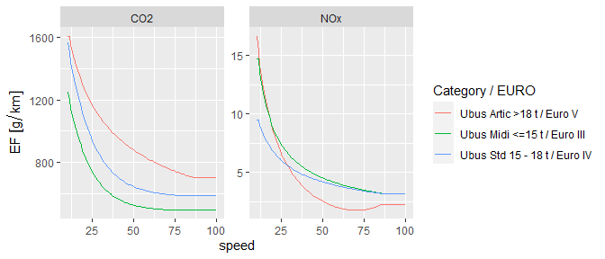

```r
setDT(ef_europe_dt)
ef_europe_dt[,name_fleet := paste0(veh_type, " / Euro ", euro)]

# plot
library(ggplot2)
ggplot(ef_europe_dt) +
  geom_line(aes(x = speed,y = EF,color = name_fleet))+
  labs(color = "Category / EURO")+
  facet_wrap(~pollutant,scales = "free")
```

**4. Emissions estimates**

As the emissions varies with `shape_id` and `fleet`, we compute emissions separately, in a loop.

```r
linestring_poa$shape_id %>% unique()
```

```
#> [1] "176-1"  "A141-1" "R10-2"  "T2-1"
```

```r
emi_data <- lapply(unique(gps_poa$shape_id),function(i){
  tmp_ef_euro <- ef_emep_europe(speed = linestring_poa[shape_id == i]$speed,
                                ,veh_type = fleet_data_ef_europe[shape_id == i]$veh_type
                                ,euro =  fleet_data_ef_europe[shape_id == i]$euro
                                ,pollutant = c("CO2","NOx")
                                ,fuel =  fleet_data_ef_europe[shape_id == i]$fuel
                                ,tech =  fleet_data_ef_europe[shape_id == i]$tech
                                ,as_list = TRUE)
  tmp_emis <- emis(fleet_composition = fleet_data_ef_europe[shape_id == i]$fleet_composition
                   ,dist = units::set_units(linestring_poa[shape_id == i]$dist,"km")
                   ,ef = tmp_ef_euro
                   ,aggregate = FALSE
                   ,as_list = TRUE)
  return(tmp_emis)
})
```

**5. Emission into grid**

We now show the example for `CO2` emissions.

```r
# Create Grid
grid_gps <- vein::make_grid(spobj = sf::st_as_sf(linestring_poa$geometry)
                            , width =  0.25 / 102.47) # 500 meters
```

```
#> Number of lon points: 67
#> Number of lat points: 69
```

```r
grid_gps <- sf::st_as_sf(grid_gps)

tmp_emis_dt <- lapply(1:length(emi_data),function(i){ # i = 3
  tmp_emi_dt <- emi_to_dt(emi_list = emi_data[[i]]
                          ,emi_vars = "emi"
                          ,veh_vars = "veh_type"
                          ,pol_vars = "pollutant")
  tmp_gps <- cbind(linestring_poa[shape_id == unique(gps_poa$shape_id)[i]]
                   ,tmp_emi_dt[pollutant == "CO2"])
  tmp_gps <- sf::st_as_sf(tmp_gps)
  tmp_emi_grid <- emis_grid(data = tmp_gps
                            ,emi = "emi"
                            ,grid = grid_gps)
  return(tmp_emi_grid)
}) %>% data.table::rbindlist()
```

```
#> input data "emi" is in units: g
#> Sum of street emissions
#> emi = 26414.44 g
#> Sum of gridded emissions
#> emi = 26414.44 g
#> input data "emi" is in units: g
#> Sum of street emissions
#> emi = 10568.66 g
#> Sum of gridded emissions
#> emi = 10568.66 g
#> input data "emi" is in units: g
#> Sum of street emissions
#> emi = 20276.45 g
#> Sum of gridded emissions
#> emi = 20276.45 g
#> input data "emi" is in units: g
#> Sum of street emissions
#> emi = 14566 g
#> Sum of gridded emissions
#> emi = 14566 g
```

Summing all emissions and plotting:

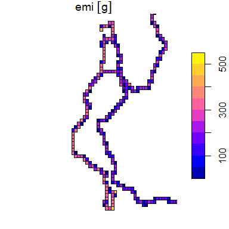

```r
tmp_emis_dt <- tmp_emis_dt[,total_emi := sum(emi), by = id][, .SD[1], by = id]
tmp_emis_dt2 <- sf::st_as_sf(tmp_emis_dt)

plot(tmp_emis_dt2["emi"])
```